# Week2_STAT433

#### 1) How many flights have a missing dep_time? What other variables are missing? What might these rows represent?

```r
library(nycflights13)
library(tidyverse)
flights
```

```
## # A tibble: 336,776 x 19
##     year month   day dep_time sched_dep_time dep_delay arr_time sched_arr_time
##    <int> <int> <int>    <int>          <int>     <dbl>    <int>          <int>
##  1  2013     1     1      517            515         2      830            819
##  2  2013     1     1      533            529         4      850            830
##  3  2013     1     1      542            540         2      923            850
##  4  2013     1     1      544            545        -1     1004           1022
##  5  2013     1     1      554            600        -6      812            837
##  6  2013     1     1      554            558        -4      740            728
##  7  2013     1     1      555            600        -5      913            854
##  8  2013     1     1      557            600        -3      709            723
##  9  2013     1     1      557            600        -3      838            846
## 10  2013     1     1      558            600        -2      753            745
## # … with 336,766 more rows, and 11 more variables: arr_delay <dbl>,
## #   carrier <chr>, flight <int>, tailnum <chr>, origin <chr>, dest <chr>,
## #   air_time <dbl>, distance <dbl>, hour <dbl>, minute <dbl>, time_hour <dttm>
```

Looking at the na values of each column.

```r
colSums(is.na(flights))
```

```
##           year          month            day       dep_time sched_dep_time
##              0              0              0           8255              0
##      dep_delay       arr_time sched_arr_time      arr_delay        carrier
##           8255           8713              0           9430              0
##         flight        tailnum         origin           dest       air_time
##              0           2512              0              0           9430
##       distance           hour         minute      time_hour
##              0              0              0              0
```

##### Comments

1. Therefore the missing departure time & delays and arrival time & delays can suggest that the flight was cancelled altogether.
2. However there are more number of null values in arrival time compared to departure time which suggests that these flights were either diverted to another airport or cancelled due to some circumstances.
3. For the rows of data where the arrival delay is a null value but arrival time has a value present, it is most likely that the flights would have been diverted and it did not reach the original destination.

#### 2) Currently dep_time and sched_dep_time are convenient to look at, but hard to compute with because theyre not really continuous numbers. Convert them to a more convenient representation of number of minutes since midnight.

```r
flights <- mutate(flights,
       dep_time_mins=(flights$dep_time%/%100*60)+flights$dep_time%%100,
       arr_time_mins=(flights$arr_time%/%100*60)+flights$arr_time%%100)
flights
```

```
## # A tibble: 336,776 x 21
##     year month   day dep_time sched_dep_time dep_delay arr_time sched_arr_time
##    <int> <int> <int>    <int>          <int>     <dbl>    <int>          <int>
##  1  2013     1     1      517            515         2      830            819
##  2  2013     1     1      533            529         4      850            830
##  3  2013     1     1      542            540         2      923            850
##  4  2013     1     1      544            545        -1     1004           1022
##  5  2013     1     1      554            600        -6      812            837
##  6  2013     1     1      554            558        -4      740            728
##  7  2013     1     1      555            600        -5      913            854
##  8  2013     1     1      557            600        -3      709            723
##  9  2013     1     1      557            600        -3      838            846
## 10  2013     1     1      558            600        -2      753            745
## # … with 336,766 more rows, and 13 more variables: arr_delay <dbl>,
## #   carrier <chr>, flight <int>, tailnum <chr>, origin <chr>, dest <chr>,
## #   air_time <dbl>, distance <dbl>, hour <dbl>, minute <dbl>, time_hour <dttm>,
## #   dep_time_mins <dbl>, arr_time_mins <dbl>
```

#### 3) Look at the number of cancelled flights per day. Is there a pattern? Is the proportion of cancelled flights related to the average delay? Use multiple dyplr operations, all on one line, concluding with ‘ggplot(aes(x= ,y=)) + geom_point()’

##### Comments

A flight is cancelled when there is no departure time or arrival time.

```r
flights_freq <- flights %>%
  mutate(cancelled = (is.na(flights$dep_delay)|is.na(flights$arr_delay))) %>% # considers for cases 1 and 2
  group_by(year, month,day) %>%
  summarise(cancelled_num = sum(cancelled)) %>% # calculates the frequency cancelled flights per day
  ungroup()
flights_freq <- flights_freq %>% mutate(day_num=(1:nrow(flights_freq)))
flights_freq
```

```
## # A tibble: 365 x 5
##     year month   day cancelled_num day_num
##    <int> <int> <int>         <int>   <int>
##  1  2013     1     1            11       1
##  2  2013     1     2            15       2
##  3  2013     1     3            14       3
##  4  2013     1     4             7       4
##  5  2013     1     5             3       5
##  6  2013     1     6             3       6
##  7  2013     1     7             3       7
##  8  2013     1     8             7       8
##  9  2013     1     9             9       9
## 10  2013     1    10             3      10
## # … with 355 more rows
```

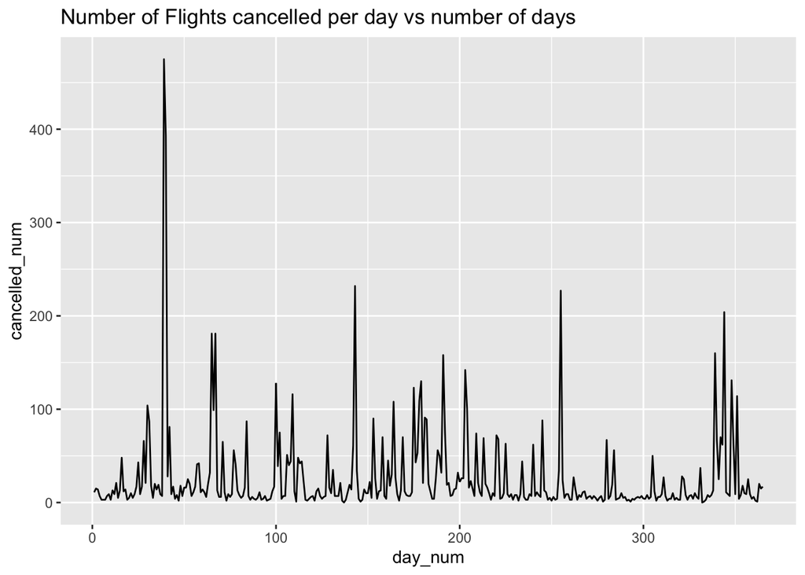

```r
ggplot(flights_freq, aes(x=day_num, y=cancelled_num)) +
  geom_line() +
  ggtitle("Number of Flights cancelled per day vs number of days")
```

#### Comments

This shows that there was an irregular jump in the number of cancelled flights during late January and early Feb.

```r
summary(flights_freq)
```

```
##       year          month             day        cancelled_num       day_num
##  Min.   :2013   Min.   : 1.000   Min.   : 1.00   Min.   :  0.00   Min.   :  1
##  1st Qu.:2013   1st Qu.: 4.000   1st Qu.: 8.00   1st Qu.:  5.00   1st Qu.: 92
##  Median :2013   Median : 7.000   Median :16.00   Median :  9.00   Median :183
##  Mean   :2013   Mean   : 6.526   Mean   :15.72   Mean   : 25.84   Mean   :183
##  3rd Qu.:2013   3rd Qu.:10.000   3rd Qu.:23.00   3rd Qu.: 23.00   3rd Qu.:274
##  Max.   :2013   Max.   :12.000   Max.   :31.00   Max.   :475.00   Max.   :365
```

```r
filter(flights_freq,cancelled_num==475)
```

```
## # A tibble: 1 x 5
##    year month   day cancelled_num day_num
##   <int> <int> <int>         <int>   <int>
## 1  2013     2     8           475      39
```

#### Comments

Interesting find: The spike in the number of the cancelled flights shows that something went down around 8th February 2013. After looking up I found that this was the time when the February 2013th North American blizzard hit the USA.

```r
delay_freq <- flights %>%
  mutate(cancelled=(is.na(flights$dep_delay)|is.na(flights$arr_delay))) %>%
  group_by(year,month,day) %>%
  summarise(cancelled_num = sum(cancelled), cancelled_mean=mean(cancelled), mean_dep_delay = mean(dep_delay,na.rm=TRUE),mean_arr_delay=mean(arr_delay,na.rm=TRUE)) %>%
  ungroup()

delay_freq
```

```
## # A tibble: 365 x 7
##     year month   day cancelled_num cancelled_mean mean_dep_delay mean_arr_delay
##    <int> <int> <int>         <int>          <dbl>          <dbl>          <dbl>
##  1  2013     1     1            11        0.0131           11.5          12.7
##  2  2013     1     2            15        0.0159           13.9          12.7
##  3  2013     1     3            14        0.0153           11.0           5.73
##  4  2013     1     4             7        0.00765           8.95         -1.93
##  5  2013     1     5             3        0.00417           5.73         -1.53
##  6  2013     1     6             3        0.00361           7.15          4.24
##  7  2013     1     7             3        0.00322           5.42         -4.95
##  8  2013     1     8             7        0.00779           2.55         -3.23
##  9  2013     1     9             9        0.00998           2.28         -0.264
## 10  2013     1    10             3        0.00322           2.84         -5.90
## # … with 355 more rows
```

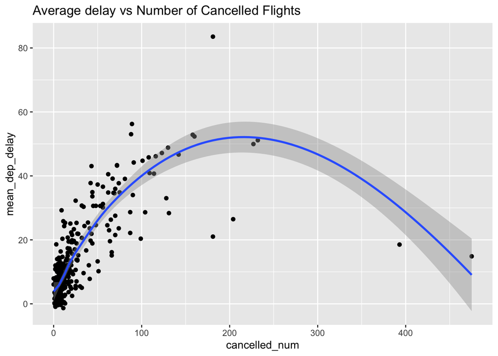

```r
ggplot(delay_freq,aes(x=cancelled_num,y=mean_dep_delay)) +
  geom_point() +
  geom_smooth() +
  ggtitle("Average delay vs Number of Cancelled Flights")
```

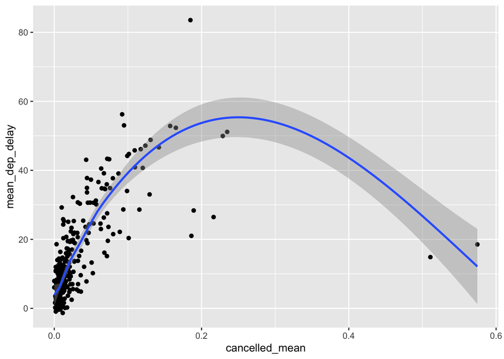

```r
ggplot(delay_freq,aes(x=cancelled_mean,y=mean_dep_delay)) + geom_point() +geom_smooth()
```